# Week 4 Assignment: Health and Economic Impacts of Severe Weather

## Instructions

Storms and other severe weather events can cause both public health and economic problems for communities and municipalities. Many severe events can result in fatalities, injuries, and property damage, and preventing such outcomes to the extent possible is a key concern.  
This project involves exploring the U.S. National Oceanic and Atmospheric Administration’s (NOAA) storm database. This database tracks characteristics of major storms and weather events in the United States, including when and where they occur, as well as estimates of any fatalities, injuries, and property damage.

The basic goal of this assignment is to explore the NOAA Storm Database and answer some basic questions about severe weather events. You must use the database to answer the questions below and show the code for your entire analysis. Your analysis can consist of tables, figures, or other summaries. You may use any R package you want to support your analysis.

## Data

The data for this assignment come in the form of a comma-separated-value file compressed via the bzip2 algorithm to reduce its size. The data for this assignment can be downloaded from here

The events in the database start in the year 1950 and end in November 2011. In the earlier years of the database there are generally fewer events recorded, most likely due to a lack of good records. More recent years should be considered more complete.

## Synopsis

The following analysis answers the follwing two questions:  
1. Across the United States, which types of events (as indicated in the ENVTYPE variable) are most harmful with respect to population health?  
2. Across the United States, which types of events have the greatest economic consequences?

## Preprocessing

### Loading and preprocessing the data

1. Environment setup

```r
library(dplyr)
library(ggplot2)
```

2. Read in the data

```r
if (!file.exists('data2.csv.bz2')){
  download.file('https://d396qusza40orc.cloudfront.net/repdata%2Fdata%2FStormData.csv.bz2',
                destfile = paste0(getwd(), '/data2.csv.bz2'),
                method = 'curl', quiet = T)
}
raw <- read.csv('data2.csv.bz2', stringsAsFactors = F)
```

3. Inspect the data

```r
names(raw)
```

```
##  [1] "STATE__"    "BGN_DATE"   "BGN_TIME"   "TIME_ZONE"  "COUNTY"
##  [6] "COUNTYNAME" "STATE"      "EVTYPE"     "BGN_RANGE"  "BGN_AZI"
## [11] "BGN_LOCATI" "END_DATE"   "END_TIME"   "COUNTY_END" "COUNTYENDN"
## [16] "END_RANGE"  "END_AZI"    "END_LOCATI" "LENGTH"     "WIDTH"
## [21] "F"          "MAG"        "FATALITIES" "INJURIES"   "PROPDMG"
## [26] "PROPDMGEXP" "CROPDMG"    "CROPDMGEXP" "WFO"        "STATEOFFIC"
## [31] "ZONENAMES"  "LATITUDE"   "LONGITUDE"  "LATITUDE_E" "LONGITUDE_"
## [36] "REMARKS"    "REFNUM"
```

4. Select data  
   Since we’re only interested in the correlation of the nation-wide event type to health and economic consequense, only the following columns will be selected for further analysis:
- EVTYPE: event type
- FATALITIES: number of fatalities
- INJURIES: number of injuries
- PROPDMG: property damage (dollars)
- PROPDMGEXP: magnitude of property damage (K = thousands, M = millions, B = billions)
- CROPDMG: crop damage (dollars)
- CROPDMGEXP: magnitude of crop damage (H = hundreds, K = thousands, M = millions, B = billions)

```r
selectCol <- c('EVTYPE', 'FATALITIES', 'INJURIES', 'PROPDMG', 'PROPDMGEXP', 'CROPDMG', 'CROPDMGEXP')
rawSel <- raw[, selectCol]
summary(rawSel)
```

```
##     EVTYPE            FATALITIES          INJURIES
##  Length:902297      Min.   :  0.0000   Min.   :   0.0000
##  Class :character   1st Qu.:  0.0000   1st Qu.:   0.0000
##  Mode  :character   Median :  0.0000   Median :   0.0000
##                     Mean   :  0.0168   Mean   :   0.1557
##                     3rd Qu.:  0.0000   3rd Qu.:   0.0000
##                     Max.   :583.0000   Max.   :1700.0000
##     PROPDMG         PROPDMGEXP           CROPDMG         CROPDMGEXP
##  Min.   :   0.00   Length:902297      Min.   :  0.000   Length:902297
##  1st Qu.:   0.00   Class :character   1st Qu.:  0.000   Class :character
##  Median :   0.00   Mode  :character   Median :  0.000   Mode  :character
##  Mean   :  12.06                      Mean   :  1.527
##  3rd Qu.:   0.50                      3rd Qu.:  0.000
##  Max.   :5000.00                      Max.   :990.000
```

## Data analysis

### Find types of events that are most harmful with respect to population health

- Make a table that counts the total fatalities and injuries in each event type

```r
Q1data <- rawSel[, 1:3] %>%
  group_by(EVTYPE) %>%
  summarise_all(sum)
summary(Q1data)
```

```
##     EVTYPE            FATALITIES         INJURIES
##  Length:985         Min.   :   0.00   Min.   :    0.0
##  Class :character   1st Qu.:   0.00   1st Qu.:    0.0
##  Mode  :character   Median :   0.00   Median :    0.0
##                     Mean   :  15.38   Mean   :  142.7
##                     3rd Qu.:   0.00   3rd Qu.:    0.0
##                     Max.   :5633.00   Max.   :91346.0
```

- Find the top 10 event types that causes the most fatalities

```r
topFat <- Q1data[order(Q1data$FATALITIES, decreasing = T), ]
```

- Find the top 10 event types that causes the most injuries

```r
topInj <- Q1data[order(Q1data$INJURIES, decreasing = T), ]
```

- Find the top 10 event types that causes the most fatalities and injuries

```r
Q1data$total <- rowSums(Q1data[, 2:3])
topHealth <- Q1data[order(Q1data$total, decreasing = T), ]
```

### Find types of events that have the greatest economic consequences

The actual values are encoded in the ‘EXP’ column for property and crop damage

```r
unique(rawSel$PROPDMGEXP)
```

```
##  [1] "K" "M" ""  "B" "m" "+" "0" "5" "6" "?" "4" "2" "3" "h" "7" "H" "-"
## [18] "1" "8"
```

- Write a function that transform the ‘EXP’ column to the factor value of 10 (10**expType)

```r
getVal <- function(expType) {
  if (expType %in% c('h', 'H')) {
    return(2)
  } else if (expType %in% c('k', 'K')) {
    return(3)
  } else if (expType %in% c('m', 'M')) {
    return(6)
  } else if (expType %in% c('b', 'B')) {
    return(9)
  } else if (suppressWarnings(!is.na(as.numeric(expType)))) {
    #won't show: NAs introduced by coercion when given a non-number
    return(as.numeric(expType))
  } else {
    return(0)
  }
}
```

- Unit testing

```r
c(10**getVal('h'), 10**getVal(4), 10**getVal('B'), 10**getVal('?'))
```

```
## [1] 1e+02 1e+04 1e+09 1e+00
```

- Make a table that applys the function and calculates the actual value

```r
Q2data <- rawSel[, c(1, 4:7)] %>%
  rowwise() %>%
  mutate(PROP = PROPDMG*10**getVal(PROPDMGEXP),
         CROP = CROPDMG*10**getVal(CROPDMGEXP))
head(Q2data)
```

```
## # A tibble: 6 x 7
##   EVTYPE  PROPDMG PROPDMGEXP CROPDMG CROPDMGEXP   PROP  CROP
##   <chr>     <dbl> <chr>        <dbl> <chr>       <dbl> <dbl>
## 1 TORNADO   25.0  K               0. ""         25000.    0.
## 2 TORNADO    2.50 K               0. ""          2500.    0.
## 3 TORNADO   25.0  K               0. ""         25000.    0.
## 4 TORNADO    2.50 K               0. ""          2500.    0.
## 5 TORNADO    2.50 K               0. ""          2500.    0.
## 6 TORNADO    2.50 K               0. ""          2500.    0.
```

```r
Q2dataSum <- Q2data[, c(1, 6, 7)] %>%
  group_by(EVTYPE) %>%
  summarise_all(sum)
summary(Q2dataSum)
```

```
##     EVTYPE               PROP                CROP
##  Length:985         Min.   :0.000e+00   Min.   :0.000e+00
##  Class :character   1st Qu.:0.000e+00   1st Qu.:0.000e+00
##  Mode  :character   Median :0.000e+00   Median :0.000e+00
##                     Mean   :4.347e+08   Mean   :4.985e+07
##                     3rd Qu.:5.105e+04   3rd Qu.:0.000e+00
##                     Max.   :1.447e+11   Max.   :1.397e+10
```

- Find the top 10 event types that causes the most property damage

```r
topProp <- Q2dataSum[order(Q2dataSum$PROP, decreasing = T), ]
```

- Find the top 10 event types that causes the most crop damage

```r
topCrop <- Q2dataSum[order(Q2dataSum$CROP, decreasing = T), ]
```

- Find toe top 10 event types that causes the most property and crop damages

```r
Q2dataSum$total <- rowSums(Q2dataSum[, 2:3])
topEcon <- Q2dataSum[order(Q2dataSum$total, decreasing = T), ]
```

## Results

### Find types of events that are most harmful with respect to population health

If separated by fatalities and injuries, the top 10 events that causes the most

- fatilities

```r
topFat[1:10, ]
```

```
## # A tibble: 10 x 3
##    EVTYPE         FATALITIES INJURIES
##    <chr>               <dbl>    <dbl>
##  1 TORNADO             5633.   91346.
##  2 EXCESSIVE HEAT      1903.    6525.
##  3 FLASH FLOOD          978.    1777.
##  4 HEAT                 937.    2100.
##  5 LIGHTNING            816.    5230.
##  6 TSTM WIND            504.    6957.
##  7 FLOOD                470.    6789.
##  8 RIP CURRENT          368.     232.
##  9 HIGH WIND            248.    1137.
## 10 AVALANCHE            224.     170.
```

- injuries

```r
topInj[1:10, ]
```

```
## # A tibble: 10 x 3
##    EVTYPE            FATALITIES INJURIES
##    <chr>                  <dbl>    <dbl>
##  1 TORNADO                5633.   91346.
##  2 TSTM WIND               504.    6957.
##  3 FLOOD                   470.    6789.
##  4 EXCESSIVE HEAT         1903.    6525.
##  5 LIGHTNING               816.    5230.
##  6 HEAT                    937.    2100.
##  7 ICE STORM                89.    1975.
##  8 FLASH FLOOD             978.    1777.
##  9 THUNDERSTORM WIND       133.    1488.
## 10 HAIL                     15.    1361.
```

If adding the numbers of fatalities and injuries and ranked by the total number, the top 10 events that causes the most population health are as follows

```r
topHealth[1:10, ]
```

```
## # A tibble: 10 x 4
##    EVTYPE            FATALITIES INJURIES  total
##    <chr>                  <dbl>    <dbl>  <dbl>
##  1 TORNADO                5633.   91346. 96979.
##  2 EXCESSIVE HEAT         1903.    6525.  8428.
##  3 TSTM WIND               504.    6957.  7461.
##  4 FLOOD                   470.    6789.  7259.
##  5 LIGHTNING               816.    5230.  6046.
##  6 HEAT                    937.    2100.  3037.
##  7 FLASH FLOOD             978.    1777.  2755.
##  8 ICE STORM                89.    1975.  2064.
##  9 THUNDERSTORM WIND       133.    1488.  1621.
## 10 WINTER STORM            206.    1321.  1527.
```

The following figure depicts top 10 event types that causes population health hazards (sum of fatalities and injuries)

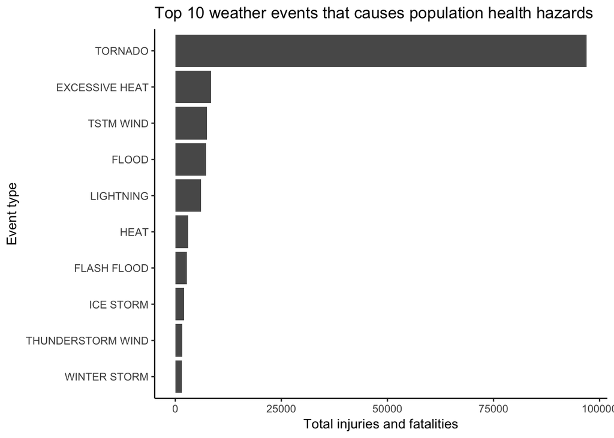

```r
ggplot(data = topHealth[1:10, ], aes(x = reorder(EVTYPE, total), y = total)) +
  #need to use reorder to prevent the categorical data from reordering
  geom_bar(stat = 'identity') +
  coord_flip() +
  xlab('Event type') +
  ylab('Total injuries and fatalities') +
  ggtitle('Top 10 weather events that causes population health hazards') +
  theme_classic()
```

**As the figure is shown, tornados are the most dangerous weather event that causes injuries and fatalities**

### Find types of events that have the greatest economic consequences

If separated by property and crop damages, the top 10 events that causes the most

- property damage

```r
topProp[1:10, ]
```

```
## # A tibble: 10 x 3
##    EVTYPE                     PROP        CROP
##    <chr>                     <dbl>       <dbl>
##  1 FLOOD             144657709807. 5661968450.
##  2 HURRICANE/TYPHOON  69305840000. 2607872800.
##  3 TORNADO            56947380676.  414953270.
##  4 STORM SURGE        43323536000.       5000.
##  5 FLASH FLOOD        16822673978. 1421317100.
##  6 HAIL               15735267513. 3025954473.
##  7 HURRICANE          11868319010. 2741910000.
##  8 TROPICAL STORM      7703890550.  678346000.
##  9 WINTER STORM        6688497251.   26944000.
## 10 HIGH WIND           5270046295.  638571300.
```

- crop damage

```r
topCrop[1:10, ]
```

```
## # A tibble: 10 x 3
##    EVTYPE                     PROP         CROP
##    <chr>                     <dbl>        <dbl>
##  1 DROUGHT             1046106000. 13972566000.
##  2 FLOOD             144657709807.  5661968450.
##  3 RIVER FLOOD         5118945500.  5029459000.
##  4 ICE STORM           3944927860.  5022113500.
##  5 HAIL               15735267513.  3025954473.
##  6 HURRICANE          11868319010.  2741910000.
##  7 HURRICANE/TYPHOON  69305840000.  2607872800.
##  8 FLASH FLOOD        16822673978.  1421317100.
##  9 EXTREME COLD          67737400.  1292973000.
## 10 FROST/FREEZE           9480000.  1094086000.
```

If combining the amounts lost in property and crop damage and ranked by the total number, the top 10 events that causes the most economic damages are

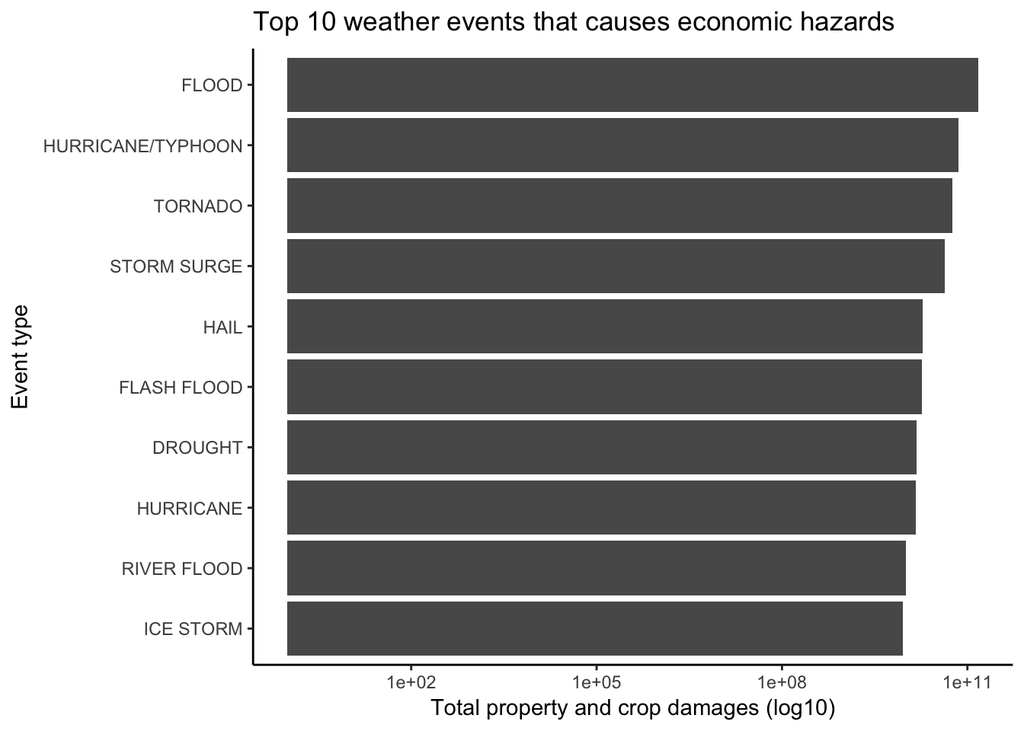

```r
ggplot(data = topEcon[1:10, ], aes(x = reorder(EVTYPE, total), y = total)) +
  #need to use reorder to prevent the categorical data from reordering
  geom_bar(stat = 'identity') +
  coord_flip() +
  scale_y_continuous(trans = 'log10') +
  xlab('Event type') +
  ylab('Total property and crop damages (log10)') +
  ggtitle('Top 10 weather events that causes economic hazards') +
  theme_classic()
```

```r
summary(topEcon[, -4])
```

```
##     EVTYPE               PROP                CROP
##  Length:985         Min.   :0.000e+00   Min.   :0.000e+00
##  Class :character   1st Qu.:0.000e+00   1st Qu.:0.000e+00
##  Mode  :character   Median :0.000e+00   Median :0.000e+00
##                     Mean   :4.347e+08   Mean   :4.985e+07
##                     3rd Qu.:5.105e+04   3rd Qu.:0.000e+00
##                     Max.   :1.447e+11   Max.   :1.397e+10
```